Back to Article

###### Article Notebook

Download Source

# Classifying drug-induced webs using Topological Data Analysis

Authors

Affiliation

Guilherme Vituri F. Pinto

Unesp

Telmo

Published

January 27, 2026

Abstract

Keywords

Topological Data Analysis, Persistent homology

# 1 Setup

## 1.1 Imports

```
In [1]:
```

```julia
# === TDAweb Modules ===
using TDAweb
using TDAweb.Preprocessing: load_web, image_to_array, image_to_r2
using TDAweb.TDA: rips_pd, rich_stats, persistence_entropy,
                  vectorize_diagram, pd_distance_matrix, loocv_knn_wasserstein
using TDAweb.Analysis: mds_embedding, classification_report, knn_predict,
                       cross_validate, test_group_differences, stats_to_matrix,
                       cohens_d, pairwise_drug_comparison, feature_importance_permutation,
                       plot_wing_with_pd
using TDAweb.Visualization: plot_betti_curves_by_group, plot_distance_heatmap_sorted,
                            plot_3d_scatter, plot_mds_2d, plot_avg_persistence_images,
                            plot_confusion_matrix, plot_feature_importance,
                            plot_feature_boxplot

# === Data & Stats ===
using DataFrames, DataFramesMeta
using TidierFiles: list_files
using StatsBase: median, mean, zscore, std
using Distances: pairwise, Euclidean
using MultivariateStats
using PersistenceDiagrams: Wasserstein, Bottleneck

# === Plotting ===
import Plots as pt
using Images: mosaicview
```

# 2 Data Loading

## 2.1 Load Images

```
In [1]:
```

```julia
files = list_files("images")
species = map(files) do file
    split(file, "/")[2]
end

imgs = load_web.(files, blur = 2)
As = image_to_array.(imgs)
Xs = image_to_r2.(As, threshold = 0.1);
```

```
In [1]:
```

```julia
df = DataFrame(File = files, Specie = species, Image = imgs)
unique_species = unique(species)
println("Groups: ", unique_species)
println("Samples per group:")
for sp in unique_species
    n = count(==(sp), species)
    println("  $sp: $n")
end
```

```
Groups: SubString{String}["CIPERMETRINA", "CONTROL", "ENDOSULFAN", "GLIFOSATO", "SPINOSAD"]
Samples per group:
  CIPERMETRINA: 5
  CONTROL: 5
  ENDOSULFAN: 5
  GLIFOSATO: 5
  SPINOSAD: 5
```

## 2.2 Point Cloud Sampling

```
In [1]:
```

```julia
samples = map(Xs) do X
    farthest_points_sample(X, 1000)
end;
```

[output not shown]

[output cut: 26 more lines]

[output not shown]

# 3 Persistence Diagrams

## 3.1 Compute Rips Filtration

```
In [1]:
```

```julia
bcs = map(samples) do s
    rips_pd(s, cutoff = 5)
end;
```

## 3.2 Extract H0 and H1

```
In [1]:
```

```julia
# H0: connected components (web fragmentation)
# H1: loops/cycles (cells in web)
# Ripserer returns tuple of (H0, H1, ...) diagrams

# Safely extract diagrams - handle cases where diagrams might be empty or missing
bcs_0 = [length(bc) >= 1 ? bc[1] : [] for bc in bcs]
bcs_1 = [length(bc) >= 2 ? bc[2] : (length(bc) >= 1 ? bc[end] : []) for bc in bcs]

println("Number of samples: ", length(bcs))
println("H0 diagram example (first non-empty): ")
for (i, bc) in enumerate(bcs_0)
    if !isempty(bc)
        println("  Sample $i: ", length(bc), " features")
        break
    end
end
println("H1 diagram example (first non-empty): ")
for (i, bc) in enumerate(bcs_1)
    if !isempty(bc)
        println("  Sample $i: ", length(bc), " features")
        break
    end
end;
```

```
Number of samples: 25
H0 diagram example (first non-empty):
  Sample 1: 1000 features
H1 diagram example (first non-empty):
  Sample 1: 81 features
```

## 3.3 Representative Web Examples

Before diving into feature extraction and statistics, let’s visualize representative spider webs from each treatment group along with their persistence diagrams. Each panel shows:

- **Top left**: Persistence diagram (birth-death plot showing H1 cycles)
- **Top right**: Web image intensity heatmap
- **Bottom**: Point cloud sample used for TDA computation

```
In [1]:
```

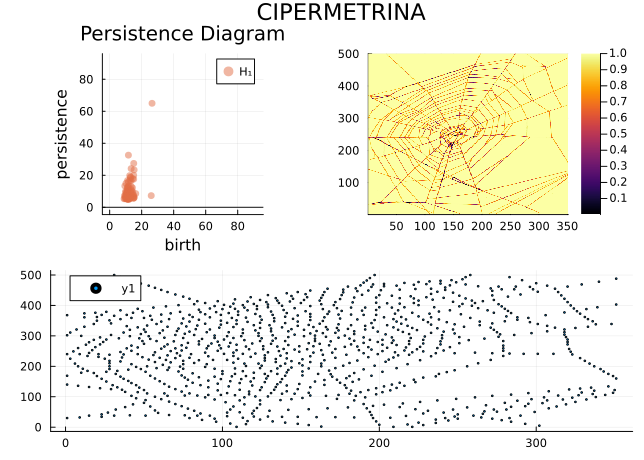

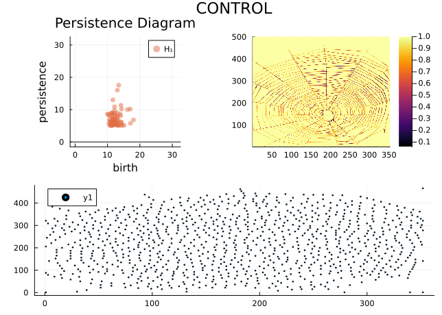

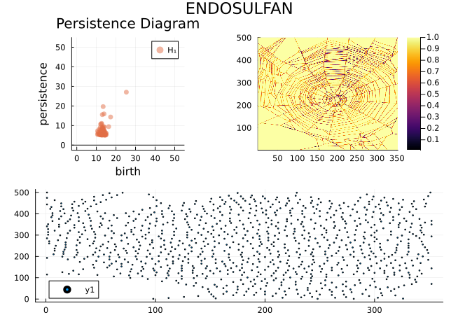

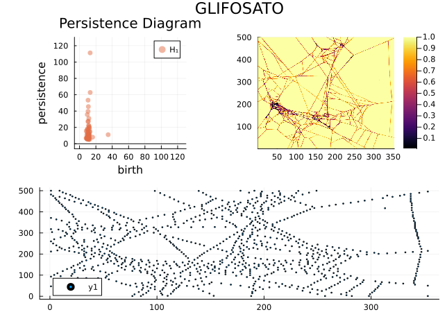

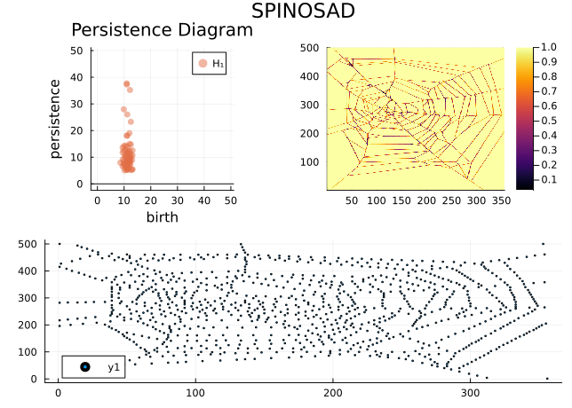

```julia
# Show one representative web per group (first sample from each)
for sp in unique_species
    idx = findfirst(==(sp), species)
    if !isnothing(idx) && !isempty(bcs_1[idx])
        p = plot_wing_with_pd(bcs_1[idx], As[idx], samples[idx], sp)
        display(p)
    end
end
```

# 4 Feature Extraction

**Understanding TDA Features**

We extract several statistical summaries from each persistence diagram. Here’s what each feature measures and how it relates to web structure:

| Feature | What it measures | Web interpretation |
| --- | --- | --- |
| **n_features** | Number of H1 cycles detected | Number of closed cells in the web |
| **total_persistence** | Sum of all cycle lifespans | Overall topological complexity |
| **mean_persistence** | Average cycle lifespan | Typical cell “robustness” |
| **max_persistence** | Largest cycle lifespan | Most prominent hole or cell |
| **entropy** | Uniformity of cycle lifespans | High = regular cells; Low = irregular cells |
| **mean_birth** | Average scale at which cycles appear | Typical cell size |

These features transform complex persistence diagrams into interpretable numbers that can be compared statistically across treatment groups.

## 4.1 Rich Statistics - H1 (Cycles)

```
In [1]:
```

```julia
stats_h1 = [rich_stats(bc) for bc in bcs_1]

DataFrame(
    Specie = species,
    n_features = [s.n_features for s in stats_h1],
    total_persistence = round.([s.total_persistence for s in stats_h1], digits=3),
    mean_persistence = round.([s.mean_persistence for s in stats_h1], digits=3),
    max_persistence = round.([s.max_persistence for s in stats_h1], digits=3),
    entropy = round.([s.entropy for s in stats_h1], digits=3)
)
```

25×6 DataFrame

| Row | Specie SubStrin… | n_features Int64 | total_persistence Float64 | mean_persistence Float64 | max_persistence Float64 | entropy Float64 |
| --- | --- | --- | --- | --- | --- | --- |
| 1 | CIPERMETRINA | 81 | 873.02 | 10.778 | 64.962 | 4.199 |
| 2 | CIPERMETRINA | 75 | 817.322 | 10.898 | 37.562 | 4.148 |
| 3 | CIPERMETRINA | 67 | 925.544 | 13.814 | 57.179 | 4.045 |
| 4 | CIPERMETRINA | 67 | 766.362 | 11.438 | 29.189 | 4.116 |
| 5 | CIPERMETRINA | 51 | 498.022 | 9.765 | 19.833 | 3.837 |
| 6 | CONTROL | 82 | 579.773 | 7.07 | 17.563 | 4.362 |
| 7 | CONTROL | 77 | 528.512 | 6.864 | 21.399 | 4.287 |
| 8 | CONTROL | 143 | 1081.29 | 7.561 | 34.722 | 4.877 |
| 9 | CONTROL | 97 | 702.172 | 7.239 | 20.042 | 4.527 |
| 10 | CONTROL | 84 | 581.866 | 6.927 | 12.214 | 4.4 |
| 11 | ENDOSULFAN | 83 | 606.581 | 7.308 | 27.047 | 4.34 |
| 12 | ENDOSULFAN | 63 | 500.55 | 7.945 | 20.962 | 4.066 |
| 13 | ENDOSULFAN | 76 | 782.878 | 10.301 | 80.165 | 4.056 |
| 14 | ENDOSULFAN | 69 | 672.232 | 9.742 | 60.978 | 3.943 |
| 15 | ENDOSULFAN | 60 | 618.495 | 10.308 | 57.41 | 3.936 |
| 16 | GLIFOSATO | 58 | 971.157 | 16.744 | 111.234 | 3.723 |
| 17 | GLIFOSATO | 45 | 723.325 | 16.074 | 60.349 | 3.52 |
| 18 | GLIFOSATO | 75 | 895.057 | 11.934 | 77.858 | 4.098 |
| 19 | GLIFOSATO | 55 | 704.198 | 12.804 | 67.047 | 3.795 |
| 20 | GLIFOSATO | 68 | 895.04 | 13.162 | 51.535 | 4.046 |
| 21 | SPINOSAD | 70 | 801.1 | 11.444 | 37.703 | 4.101 |
| 22 | SPINOSAD | 75 | 851.592 | 11.355 | 53.003 | 4.171 |
| 23 | SPINOSAD | 69 | 773.653 | 11.212 | 38.041 | 4.102 |
| 24 | SPINOSAD | 60 | 732.108 | 12.202 | 27.947 | 3.982 |
| 25 | SPINOSAD | 75 | 829.957 | 11.066 | 57.037 | 4.177 |

## 4.2 Rich Statistics - H0 (Fragmentation)

```
In [1]:
```

```julia
# H0 diagrams may be empty for some samples - handle gracefully
stats_h0 = [rich_stats(bc) for bc in bcs_0]

println("H0 Statistics (Web Fragmentation) - Mean by Group:")
for sp in unique_species
    idx = findall(==(sp), species)
    if isempty(idx)
        println("  $sp: no samples")
        continue
    end
    group_h0 = stats_h0[idx]
    components = [s.n_features for s in group_h0]
    total_pers = [s.total_persistence for s in group_h0]
    mean_components = isempty(components) ? 0.0 : mean(components)
    mean_total_pers = isempty(total_pers) ? 0.0 : mean(total_pers)
    println("  $sp: $(round(mean_components, digits=1)) components, total_pers=$(round(mean_total_pers, digits=3))")
end;
```

```
H0 Statistics (Web Fragmentation) - Mean by Group:
  CIPERMETRINA: 1000.0 components, total_pers=8565.332
  CONTROL: 1000.0 components, total_pers=11492.154
  ENDOSULFAN: 1000.0 components, total_pers=9957.6
  GLIFOSATO: 990.2 components, total_pers=7589.23
  SPINOSAD: 1000.0 components, total_pers=8002.367
```

## 4.3 Feature Matrices

```
In [1]:
```

```julia
# H1 rich stats matrix
X_h1, feature_names_h1 = stats_to_matrix(stats_h1)

# H0 rich stats matrix
X_h0, feature_names_h0 = stats_to_matrix(stats_h0)

# Safe z-score normalization (handles constant columns)
function safe_zscore(x)
    s = std(x)
    s == 0 ? zeros(length(x)) : zscore(x)
end

X_h1_normalized = mapslices(safe_zscore, X_h1, dims=1)
X_h0_normalized = mapslices(safe_zscore, X_h0, dims=1)

# Replace any NaN with 0
X_h1_normalized[isnan.(X_h1_normalized)] .= 0.0
X_h0_normalized[isnan.(X_h0_normalized)] .= 0.0

println("H1 features: ", feature_names_h1)
println("Feature matrix size: $(size(X_h1))")
```

```
H1 features: [:n_features, :total_persistence, :mean_persistence, :std_persistence, :max_persistence, :q25, :q50, :q75, :q90, :entropy, :mean_birth, :birth_range]
Feature matrix size: (25, 12)
```

## 4.4 Vectorized Diagram Features

```
In [1]:
```

```julia
# Full vectorization (persistence images, Betti curves, landscapes, etc.)
feature_vectors = [vectorize_diagram(bc) for bc in bcs_1]
X_features = reduce(hcat, feature_vectors)'

println("Vectorized features dimension: $(size(X_features, 2))")
```

```
Vectorized features dimension: 362
```

# 5 Exploratory Visualization

## 5.1 Summary Statistics by Drug

```
In [1]:
```

```julia
println("Mean Statistics by Group:\n")
for sp in unique_species
    idx = findall(==(sp), species)
    if isempty(idx)
        println("$sp: no samples\n")
        continue
    end
    group_stats = stats_h1[idx]

    entropies = [s.entropy for s in group_stats]
    n_feats = [s.n_features for s in group_stats]
    max_pers = [s.max_persistence for s in group_stats]

    mean_entropy = isempty(entropies) ? 0.0 : mean(entropies)
    mean_n_features = isempty(n_feats) ? 0.0 : mean(n_feats)
    mean_max_pers = isempty(max_pers) ? 0.0 : mean(max_pers)

    println("$sp:")
    println("  - Mean cycles (H1): $(round(mean_n_features, digits=1))")
    println("  - Mean entropy: $(round(mean_entropy, digits=3))")
    println("  - Mean max persistence: $(round(mean_max_pers, digits=3))")
    println()
end
```

```
Mean Statistics by Group:

CIPERMETRINA:
  - Mean cycles (H1): 68.2
  - Mean entropy: 4.069
  - Mean max persistence: 41.745

CONTROL:
  - Mean cycles (H1): 96.6
  - Mean entropy: 4.491
  - Mean max persistence: 21.188

ENDOSULFAN:
  - Mean cycles (H1): 70.2
  - Mean entropy: 4.068
  - Mean max persistence: 49.312

GLIFOSATO:
  - Mean cycles (H1): 60.2
  - Mean entropy: 3.836
  - Mean max persistence: 73.605

SPINOSAD:
  - Mean cycles (H1): 69.8
  - Mean entropy: 4.107
  - Mean max persistence: 42.746
```

## 5.2 Betti Curves by Drug

```
In [1]:
```

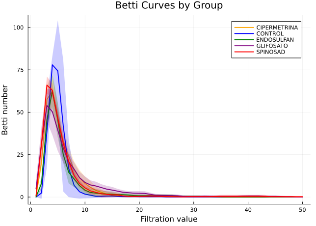

```julia
plot_betti_curves_by_group(bcs_1, species)
```

## 5.3 Average Persistence Images

```
In [1]:
```

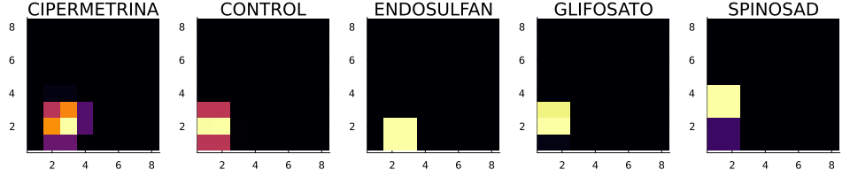

```julia
plot_avg_persistence_images(bcs_1, species; size_pi=8, sigma=0.15)
```

## 5.4 Within-Group Variability

Some drug groups show more heterogeneity in web structure than others. Below we show the most and least complex webs (by entropy) within each group to illustrate this variability. High entropy indicates regular, uniform cell sizes; low entropy indicates irregular cells.

```
In [1]:
```

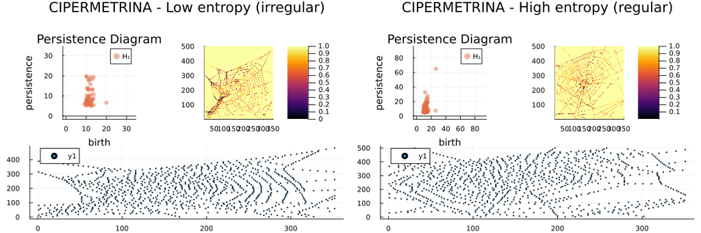

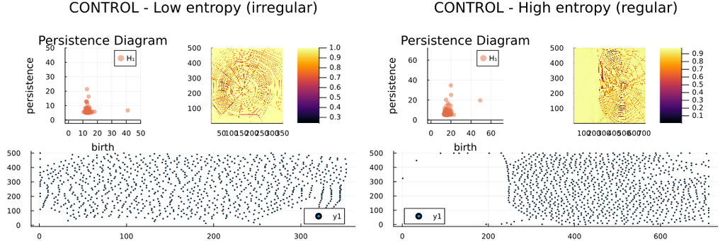

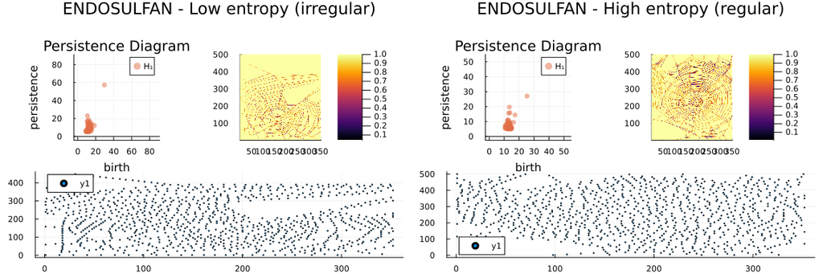

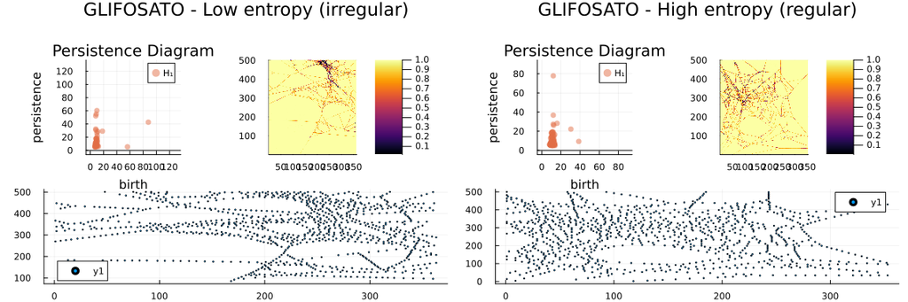

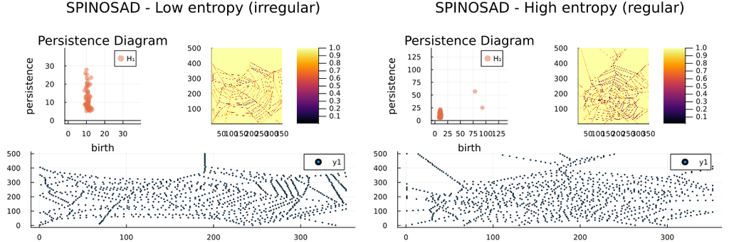

```julia
for sp in unique_species
    idx = findall(==(sp), species)
    if length(idx) >= 2
        group_entropies = [stats_h1[i].entropy for i in idx]
        sorted_idx = idx[sortperm(group_entropies)]

        low_i = sorted_idx[1]
        high_i = sorted_idx[end]

        p_low = plot_wing_with_pd(bcs_1[low_i], As[low_i], samples[low_i],
                                   "$sp - Low entropy (irregular)")
        p_high = plot_wing_with_pd(bcs_1[high_i], As[high_i], samples[high_i],
                                    "$sp - High entropy (regular)")

        combined = pt.plot(p_low, p_high, layout=(1, 2), size=(1200, 400))
        display(combined)
    end
end
```

## 5.5 Feature Distributions by Group

```
In [0]:
```

```julia
p1 = plot_feature_boxplot([s.entropy for s in stats_h1], species, "Entropy (H1)")
p2 = plot_feature_boxplot([s.n_features for s in stats_h1], species, "Number of Cycles (H1)")
p3 = plot_feature_boxplot([s.max_persistence for s in stats_h1], species, "Max Persistence (H1)")
p4 = plot_feature_boxplot([s.total_persistence for s in stats_h1], species, "Total Persistence (H1)")

pt.plot(p1, p2, p3, p4, layout=(2, 2), size=(900, 700))
```

[output not shown]

# 6 Distance Analysis

**Understanding Wasserstein Distance**

The **Wasserstein distance** (also called Earth Mover’s Distance) measures how different two persistence diagrams are.

**Intuition**: Imagine each point in a persistence diagram as a pile of dirt. The Wasserstein distance is the minimum “work” needed to transform one diagram into another by moving dirt around.

**Why use it for TDA?**

- Specifically designed for comparing persistence diagrams
- Captures both the locations of topological features and how they should be matched
- Has metric properties, enabling use with standard machine learning methods (like KNN)

**Notation**: Wasserstein(p, q) — we use p=1 (sum of movements) and q=2 (Euclidean ground metric).

A **small** Wasserstein distance means two webs have similar topological structure; a **large** distance means their persistence diagrams differ substantially.

**Understanding MDS (Multidimensional Scaling)**

**MDS** converts a distance matrix into low-dimensional coordinates for visualization:

1. Start with pairwise distances between all samples
2. Find 2D or 3D coordinates that preserve these distances as well as possible
3. Plot the coordinates — samples close together have similar features

**How to interpret MDS plots:**

- **Clusters** = groups of samples with similar topological features
- **Separation between clusters** = distinct TDA signatures between groups
- **Overlap between groups** = ambiguity; these groups are hard to distinguish topologically

MDS is purely for visualization — it doesn’t make statistical claims, but helps us see patterns before formal testing.

## 6.1 Wasserstein Distance Matrix

```
In [1]:
```

```julia
D_wasserstein = pd_distance_matrix(bcs_1; metric=Wasserstein(1, 2))
```

```
25×25 Matrix{Float64}:
   0.0    153.902  196.439   193.35   …  208.16   215.576  221.624  280.905
 153.902    0.0    174.387   135.416     149.41   177.926  157.148  232.255
 196.439  174.387    0.0     168.318     183.733  235.855  187.542  331.76
 193.35   135.416  168.318     0.0       119.282  143.572  116.677  187.359
 292.715  248.312  312.273   205.141     262.955  210.212  173.99   254.161
 308.207  290.146  416.907   274.013  …  326.023  285.463  286.87   269.717
 329.965  322.42   410.403   287.321     347.309  323.556  294.093  314.412
 603.226  643.839  671.949   632.022     681.777  697.417  668.18   769.458
 349.289  357.019  448.216   332.459     399.233  388.852  352.995  377.68
 347.025  339.839  440.027   306.999     372.626  339.874  319.151  320.637
   ⋮                                  ⋱
 429.158  365.855  389.714   397.061     381.92   363.305  363.174  436.417
 160.167  156.358  184.929   174.512     134.886  171.419  204.306  258.935
 345.248  308.022  336.994   288.08      273.004  225.198  267.986  329.7
 195.675  154.326   93.9724  155.1       163.356  226.448  175.67   318.015
 198.092  112.947  184.738   104.998  …  142.971  161.928  151.382  215.705
 208.16   149.41   183.733   119.282       0.0    139.703  168.142  217.772
 215.576  177.926  235.855   143.572     139.703    0.0    152.237  184.898
 221.624  157.148  187.542   116.677     168.142  152.237    0.0    204.981
 280.905  232.255  331.76    187.359     217.772  184.898  204.981    0.0
```

```
In [1]:
```

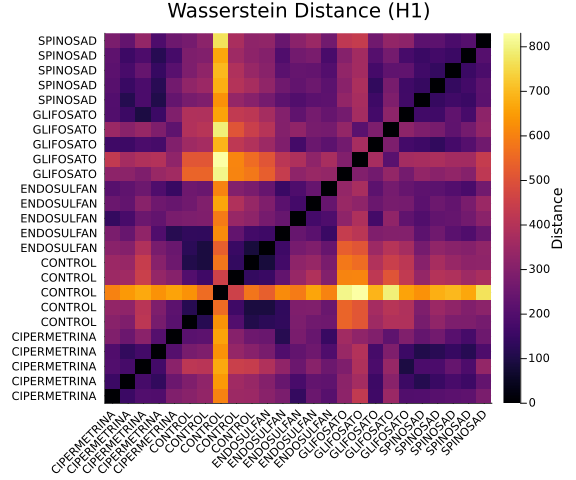

```julia
plot_distance_heatmap_sorted(D_wasserstein, species; title="Wasserstein Distance (H1)")
```

## 6.2 Euclidean Distance on Rich Stats

```
In [1]:
```

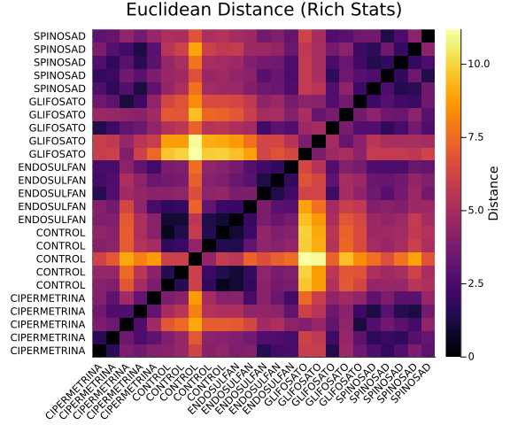

```julia
D_rich_stats = pairwise(Euclidean(), X_h1_normalized, dims=1)
plot_distance_heatmap_sorted(D_rich_stats, species; title="Euclidean Distance (Rich Stats)")
```

## 6.3 MDS Embeddings

```
In [1]:
```

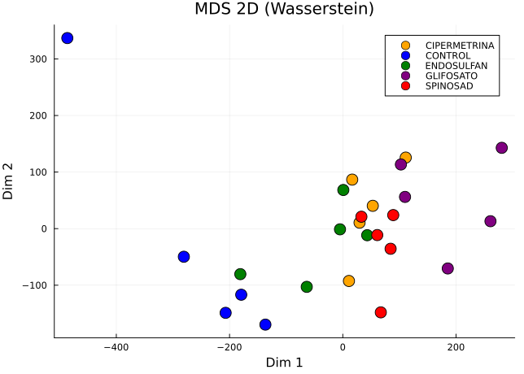

```julia
# 2D MDS - Wasserstein
mds_wass_2d = mds_embedding(D_wasserstein; maxoutdim=2)
plot_mds_2d(mds_wass_2d.embedding, species; title="MDS 2D (Wasserstein)")
```

```
In [1]:
```

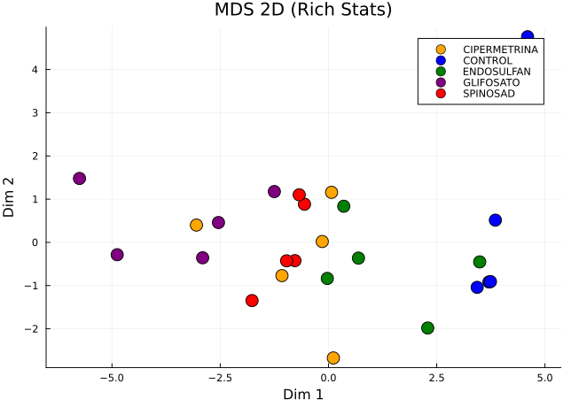

```julia
# 2D MDS - Rich Stats
mds_rich_2d = mds_embedding(D_rich_stats; maxoutdim=2)
plot_mds_2d(mds_rich_2d.embedding, species; title="MDS 2D (Rich Stats)")
```

```
In [0]:
```

```julia
# 3D MDS - Wasserstein (disabled: PlotlyJS output not compatible with Quarto)
mds_wass_3d = mds_embedding(D_wasserstein; maxoutdim=3)
plot_3d_scatter(mds_wass_3d.embedding, species; title="MDS 3D (Wasserstein H1)")
```

# 7 Statistical Tests

Our statistical analysis follows a three-stage approach:

1. **Omnibus test** (Kruskal-Wallis): Do ANY groups differ from each other?
2. **Pairwise comparisons** (Permutation tests): WHICH drugs differ from control?
3. **Effect sizes** (Cohen’s d): HOW MUCH do they differ?

This hierarchical approach controls false positives while providing interpretable effect magnitudes.

**What is the Kruskal-Wallis Test?**

The **Kruskal-Wallis test** is a non-parametric alternative to one-way ANOVA. We use it here because:

1. **No normality assumption**: Unlike ANOVA, it doesn’t require the data to follow a normal distribution — important for TDA features which may have unusual distributions
2. **Robust to outliers**: Uses ranks instead of raw values, so extreme points don’t dominate
3. **Works with small samples**: Reliable even with limited data per group

**How to interpret the p-value:**

- **p < 0.05**: Strong evidence that at least one group differs from the others (marked with *)
- **p ≥ 0.05**: Insufficient evidence to conclude groups differ

**Why not use ANOVA?** With small sample sizes and potentially non-normal distributions (common in TDA features), Kruskal-Wallis is more reliable and makes fewer assumptions.

## 7.1 Kruskal-Wallis Tests

```
In [1]:
```

```julia
println("Kruskal-Wallis Tests for Group Differences:\n")

# Test key features
features_to_test = [
    ("entropy", [s.entropy for s in stats_h1]),
    ("n_features", [s.n_features for s in stats_h1]),
    ("max_persistence", [s.max_persistence for s in stats_h1]),
    ("total_persistence", [s.total_persistence for s in stats_h1]),
]

for (name, values) in features_to_test
    kw = test_group_differences(values, species)
    sig = kw.p_value < 0.05 ? "*" : ""
    println("$name: p = $(round(kw.p_value, digits=4)) $sig")
end
```

```
Kruskal-Wallis Tests for Group Differences:

entropy: p = 0.0051 *
n_features: p = 0.0149 *
max_persistence: p = 0.0159 *
total_persistence: p = 0.1359
```

**Understanding Effect Sizes (Cohen’s d)**

A **p-value** tells you *if* groups differ statistically, but **effect size** tells you *how much* they differ in practical terms.

**Cohen’s d** measures the standardized difference between two group means:

$$d = \frac{\bar{x}_1 - \bar{x}_2}{s_{pooled}}$$

where $s_{pooled}$ is the pooled standard deviation of both groups.

**Interpretation guidelines:**

|  | d | value |
| --- | --- | --- |
| < 0.2 | Negligible | Groups nearly identical |
| 0.2 – 0.5 | Small | Detectable but minor difference |
| 0.5 – 0.8 | Medium | Noticeable practical difference |
| > 0.8 | Large | Substantial, meaningful difference |

**Why effect size matters:** With large samples, even tiny differences can be “statistically significant” (p < 0.05) but practically meaningless. Effect size helps distinguish meaningful differences from trivial ones.

**Understanding Permutation Tests**

A **permutation test** is a non-parametric method to compute p-values without assuming any particular distribution:

1. Calculate the observed difference between groups (e.g., difference in mean entropy)
2. Randomly shuffle group labels many times (e.g., 10,000 permutations)
3. Recalculate the difference after each shuffle
4. Count how often the shuffled difference exceeds the observed difference
5. p-value = (count + 1) / (n_permutations + 1)

**Advantages:**

- No distributional assumptions — works for any data
- Works with any test statistic
- Provides exact p-values even for small samples
- Intuitive interpretation: “how often would we see this difference by chance?”

**Used here:** We compare each drug group to CONTROL using permutation tests to get reliable p-values.

**A Note on Multiple Comparisons**

When we test multiple features across multiple drug groups, we increase the chance of **false positives**. With 4 drugs × 3 features = 12 tests at α = 0.05, we expect about 0.6 false positives by chance alone.

**Recommendations for interpreting results:**

- Focus on results with **p < 0.01** (more stringent threshold)
- Prioritize findings with **large effect sizes** (|d| > 0.8)
- Look for **consistent patterns** across related features (e.g., both entropy and n_cycles showing similar direction)

Results that meet multiple criteria (low p-value AND large effect size AND consistent pattern) are most reliable.

## 7.2 Pairwise Drug Comparisons with Effect Sizes

```
In [1]:
```

```julia
# Compare each drug to CONTROL with effect sizes
comparisons = vcat([
    pairwise_drug_comparison([s.entropy for s in stats_h1], species; feature_name="entropy"),
    pairwise_drug_comparison([s.n_features for s in stats_h1], species; feature_name="n_cycles"),
    pairwise_drug_comparison([s.max_persistence for s in stats_h1], species; feature_name="max_persistence"),
]...)

# Show results
select(comparisons, :drug, :feature, :diff_percent => (x -> round.(x, digits=1)) => :diff_pct,
       :cohens_d => (x -> round.(x, digits=2)) => :cohens_d, :effect_size, :p_value)
```

12×6 DataFrame

| Row | drug SubStrin… | feature String | diff_pct Float64 | cohens_d Float64 | effect_size String | p_value Float64 |
| --- | --- | --- | --- | --- | --- | --- |
| 1 | CIPERMETRINA | entropy | -9.4 | -2.19 | large | 0.0003 |
| 2 | ENDOSULFAN | entropy | -9.4 | -2.1 | large | 0.0108 |
| 3 | GLIFOSATO | entropy | -14.6 | -2.78 | large | 0.0032 |
| 4 | SPINOSAD | entropy | -8.6 | -2.21 | large | 0.0032 |
| 5 | CIPERMETRINA | n_cycles | -29.4 | -1.37 | large | 0.0164 |
| 6 | ENDOSULFAN | n_cycles | -27.3 | -1.31 | large | 0.0295 |
| 7 | GLIFOSATO | n_cycles | -37.7 | -1.75 | large | 0.0087 |
| 8 | SPINOSAD | n_cycles | -27.7 | -1.37 | large | 0.0087 |
| 9 | CIPERMETRINA | max_persistence | 97.0 | 1.41 | large | 0.0597 |
| 10 | ENDOSULFAN | max_persistence | 132.7 | 1.52 | large | 0.0479 |
| 11 | GLIFOSATO | max_persistence | 247.4 | 3.01 | large | 0.0061 |
| 12 | SPINOSAD | max_persistence | 101.7 | 2.09 | large | 0.0154 |

```
In [1]:
```

```julia
# Bonferroni correction for multiple comparisons
n_tests = nrow(comparisons)
bonf_alpha = 0.05 / n_tests
println("Multiple comparison correction:")
println("  Number of tests: $n_tests")
println("  Bonferroni-corrected α = $(round(bonf_alpha, digits=4))")
println("  Comparisons significant after correction: ", sum(comparisons.p_value .< bonf_alpha))
```

```
Multiple comparison correction:
  Number of tests: 12
  Bonferroni-corrected α = 0.0042
  Comparisons significant after correction: 3
```

# 8 Classification

Beyond hypothesis testing, we can ask: **can we automatically identify which drug a spider was exposed to based on its web’s topological features?** This is a classification task.

**What is KNN (K-Nearest Neighbors)?**

**KNN** is one of the simplest classification algorithms. To classify a new sample:

1. Compute the distance from the new sample to all training samples
2. Find the **k nearest neighbors** (k closest training samples)
3. Assign the **majority class** among those neighbors

**Key parameter: k** (number of neighbors)

- **Small k** (e.g., k=1 or k=3): More sensitive to local patterns, but also to noise
- **Large k** (e.g., k=10+): More robust, but may miss subtle differences

We use **k=3** as a balanced choice that captures local structure without being overly sensitive to outliers.

**Distance metric matters:** We test both Wasserstein distance (comparing persistence diagrams directly) and Euclidean distance (comparing extracted features).

**Why Cross-Validation? And What’s LOOCV vs K-Fold?**

**The problem:** If we train and test on the same data, we get overly optimistic accuracy because the model has “seen” the answers. We need to estimate performance on *unseen* data.

### 8.0.1 Leave-One-Out Cross-Validation (LOOCV)

1. Remove **one** sample from the dataset
2. Train the model on the remaining n-1 samples
3. Predict the class of the held-out sample
4. Repeat for **every** sample
5. Accuracy = proportion of correct predictions

**Pros:** Uses maximum training data; deterministic (same result every time) **Cons:** Computationally expensive; can have high variance

### 8.0.2 K-Fold Cross-Validation

1. Split data into **k equal folds** (e.g., k=5)
2. For each fold: train on k-1 folds, test on the remaining fold
3. Average accuracy across all folds

**Pros:** Good balance of bias and variance; faster than LOOCV **Cons:** Results vary slightly depending on random split (we report mean ± std)

### 8.0.3 Interpreting Results

- **LOOCV accuracy:** Single number, deterministic
- **K-fold accuracy:** Reported as mean ± standard deviation
- Higher accuracy = better classification; >50% for 5 classes means better than random guessing (20%)

**Understanding Classification Metrics**

Beyond overall accuracy, we report **per-class metrics**:

| Metric | What it measures | Formula |
| --- | --- | --- |
| **Precision** | Of samples predicted as class X, how many are truly X? | TP / (TP + FP) |
| **Recall** | Of samples truly in class X, how many did we identify? | TP / (TP + FN) |
| **F1 Score** | Harmonic mean of precision and recall | 2 × (P × R) / (P + R) |

**Interpreting the confusion matrix:**

- **Diagonal elements:** Correct predictions (true positives for each class)
- **Off-diagonal elements:** Errors — reading row i, column j means “sample truly in class i was predicted as class j”
- A perfect classifier has all counts on the diagonal

## 8.1 KNN with Wasserstein Distance (LOOCV)

```
In [1]:
```

```julia
result_knn_wass = loocv_knn_wasserstein(bcs_1, species; k=3)
println("Accuracy (KNN Wasserstein k=3): $(round(result_knn_wass.accuracy * 100, digits=1))%")

report_wass = classification_report(species, result_knn_wass.predictions)
println("\nPer-class metrics:")
for label in report_wass["labels"]
    m = report_wass[string(label)]
    println("  $label: precision=$(round(m.precision, digits=2)), recall=$(round(m.recall, digits=2)), f1=$(round(m.f1, digits=2))")
end
```

```
Accuracy (KNN Wasserstein k=3): 56.0%

Per-class metrics:
  CIPERMETRINA: precision=0.4, recall=0.4, f1=0.4
  CONTROL: precision=0.71, recall=1.0, f1=0.83
  ENDOSULFAN: precision=0.5, recall=0.2, f1=0.29
  GLIFOSATO: precision=1.0, recall=0.4, f1=0.57
  SPINOSAD: precision=0.44, recall=0.8, f1=0.57
```

```
In [1]:
```

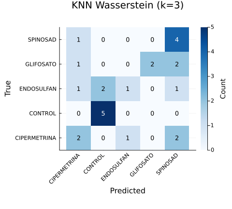

```julia
plot_confusion_matrix(species, result_knn_wass.predictions; title="KNN Wasserstein (k=3)")
```

## 8.2 KNN on Vectorized Features (5-fold CV)

```
In [1]:
```

```julia
knn_clf = (Xt, yt, Xtest) -> knn_predict(Xt, yt, Xtest; k=3)
cv_features = cross_validate(knn_clf, X_features, species; k=5)
println("Accuracy (KNN vectorized, 5-fold): $(round(cv_features.mean * 100, digits=1))% +/- $(round(cv_features.std * 100, digits=1))%")
```

```
Accuracy (KNN vectorized, 5-fold): 36.0% +/- 8.9%
```

## 8.3 KNN on Rich Stats (5-fold CV)

```
In [1]:
```

```julia
cv_rich = cross_validate(knn_clf, X_h1_normalized, species; k=5)
println("Accuracy (KNN rich stats, 5-fold): $(round(cv_rich.mean * 100, digits=1))% +/- $(round(cv_rich.std * 100, digits=1))%")
```

```
Accuracy (KNN rich stats, 5-fold): 64.0% +/- 21.9%
```

## 8.4 Classification Comparison

```
In [1]:
```

```julia
println("=== Classification Methods Comparison ===\n")
println("1. KNN Wasserstein (k=3, LOOCV):        $(round(result_knn_wass.accuracy * 100, digits=1))%")
println("2. KNN Vectorized Features (k=3, 5-fold): $(round(cv_features.mean * 100, digits=1))% +/- $(round(cv_features.std * 100, digits=1))%")
println("3. KNN Rich Stats (k=3, 5-fold):         $(round(cv_rich.mean * 100, digits=1))% +/- $(round(cv_rich.std * 100, digits=1))%")
```

```
=== Classification Methods Comparison ===

1. KNN Wasserstein (k=3, LOOCV):        56.0%
2. KNN Vectorized Features (k=3, 5-fold): 36.0% +/- 8.9%
3. KNN Rich Stats (k=3, 5-fold):         64.0% +/- 21.9%
```

# 9 Feature Importance

```
In [1]:
```

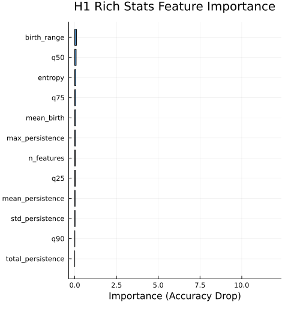

```julia
# Compute feature importance via permutation
importances = feature_importance_permutation(knn_clf, X_h1_normalized, species; n_repeats=20)
plot_feature_importance(importances, feature_names_h1; top_n=12, title="H1 Rich Stats Feature Importance")
```

```
In [1]:
```

```julia
# Show importance values
importance_df = DataFrame(
    feature = feature_names_h1,
    importance = round.(importances, digits=4)
)
sort(importance_df, :importance, rev=true)
```

12×2 DataFrame

| Row | feature Symbol | importance Float64 |
| --- | --- | --- |
| 1 | birth_range | 0.104 |
| 2 | q50 | 0.086 |
| 3 | entropy | 0.06 |
| 4 | q75 | 0.054 |
| 5 | mean_birth | 0.046 |
| 6 | max_persistence | 0.044 |
| 7 | n_features | 0.036 |
| 8 | q25 | 0.034 |
| 9 | mean_persistence | 0.026 |
| 10 | std_persistence | 0.024 |
| 11 | q90 | 0.01 |
| 12 | total_persistence | 0.004 |

# 10 Biological Interpretation

## 10.1 Feature Meaning

| Dimension | Web Structure | Interpretation |
| --- | --- | --- |
| H0 (components) | Disconnected fragments | More H0 = broken/fragmented web |
| H1 (loops/cycles) | Closed cells/meshes | More H1 = more closed cells |
| Entropy H1 | Cell uniformity | High entropy = regular cells |
| Max persistence H1 | Largest hole/gap | High = large gap in web |

## 10.2 Drug Effects Summary

```
In [1]:
```

```julia
# Compare each drug to control
control_idx = findall(==("CONTROL"), species)
if isempty(control_idx)
    println("No CONTROL group found")
else
    control_stats = stats_h1[control_idx]
    control_entropies = [s.entropy for s in control_stats]
    control_h1_counts = [s.n_features for s in control_stats]
    control_mean_entropy = isempty(control_entropies) ? 0.0 : mean(control_entropies)
    control_mean_h1 = isempty(control_h1_counts) ? 0.0 : mean(control_h1_counts)

    println("Drug Effects Compared to CONTROL:\n")
    println("CONTROL baseline - Entropy: $(round(control_mean_entropy, digits=3)), H1 count: $(round(control_mean_h1, digits=1))\n")

    for sp in unique_species
        sp == "CONTROL" && continue

        idx = findall(==(sp), species)
        if isempty(idx)
            println("$sp: no samples\n")
            continue
        end
        drug_stats = stats_h1[idx]

        drug_entropies = [s.entropy for s in drug_stats]
        drug_h1_counts = [s.n_features for s in drug_stats]
        drug_entropy = isempty(drug_entropies) ? 0.0 : mean(drug_entropies)
        drug_h1 = isempty(drug_h1_counts) ? 0.0 : mean(drug_h1_counts)

        effects = String[]

        if drug_h1 < control_mean_h1 * 0.8
            push!(effects, "Fewer closed cells")
        elseif drug_h1 > control_mean_h1 * 1.2
            push!(effects, "More cells than control")
        end

        if drug_entropy < control_mean_entropy * 0.9
            push!(effects, "More irregular cells")
        elseif drug_entropy > control_mean_entropy * 1.1
            push!(effects, "More regular cells")
        end

        effect_str = isempty(effects) ? "Similar to control" : join(effects, ", ")

        # Safe division (avoid div by zero)
        ent_pct = control_mean_entropy == 0 ? 0.0 : (drug_entropy/control_mean_entropy - 1)*100
        h1_pct = control_mean_h1 == 0 ? 0.0 : (drug_h1/control_mean_h1 - 1)*100

        println("$sp:")
        println("  Entropy: $(round(drug_entropy, digits=3)) ($(round(ent_pct, digits=1))%)")
        println("  H1 count: $(round(drug_h1, digits=1)) ($(round(h1_pct, digits=1))%)")
        println("  Effect: $effect_str")
        println()
    end
end
```

```
Drug Effects Compared to CONTROL:

CONTROL baseline - Entropy: 4.491, H1 count: 96.6

CIPERMETRINA:
  Entropy: 4.069 (-9.4%)
  H1 count: 68.2 (-29.4%)
  Effect: Fewer closed cells

ENDOSULFAN:
  Entropy: 4.068 (-9.4%)
  H1 count: 70.2 (-27.3%)
  Effect: Fewer closed cells

GLIFOSATO:
  Entropy: 3.836 (-14.6%)
  H1 count: 60.2 (-37.7%)
  Effect: Fewer closed cells, More irregular cells

SPINOSAD:
  Entropy: 4.107 (-8.6%)
  H1 count: 69.8 (-27.7%)
  Effect: Fewer closed cells
```